# Laboratório 04

James Sampaio

04 de julho, 2025

# Orientações

Inicialmente, você deve criar um R Notebook. Salve o arquivo com o nome `sua_matricula.Rmd` e apague todo o conteúdo do arquivo automaticamente gerado. Feito isso, siga as instruções abaixo.

#### Apresentação da avaliação

- Crie um cabeçalho YAML com título, nome completo e matrícula dos autores; e a data de hoje. Inspire-se neste arquivo.
- Divida o seu arquivo em partes, como neste arquivo. Lembre-se, basta utilizar os `#`’s.
- Enumere a solução dos exercícios com o mesmo número atribuído neste documento.
- Todos os códigos devem estar disponíveis no arquivo. Exceto se, no corpo do texto do exercício, for orientado o contrário.
- O não cumprimento de qualquer dessas orientações acarretará o decréscimo de 0,5 pontos na nota da avaliação.

#### Recursos para a solução

- O trabalho pode ser realizado em duplas ou individualmente.
- Suspeitas de plágio e compartilhamento de soluções serão tratadas com rigor.

# Parte 1

Vocês irão trabalhar com alguns bancos de dados nesta avaliação. O banco de dados `def_area_1988_2022.csv` contém dados sobre a área desmatada ($km^2$), entre os anos de 1988 a 2022 para todos os estados da Amazônia Legal, organizados pelo Programa de Monitoramento da Floresta Amazônica Brasileira por Satélite ([PRODES](http://www.obt.inpe.br/OBT/assuntos/programas/amazonia/prodes)). O banco de dados `inpe_brazilian_amazon_fires_1999_2022.csv` contém registros da quantidade de focos de incêndio na Amazônia Legal por estado, mês e ano, de 1999 a 2022. O dados são geridos pelo Instituto Nacional de Pesquisas Espaciais (INPE) em seu programa Banco de Dados de Queimada ([BDQ](https://queimadas.dgi.inpe.br/queimadas/bdqueimadas/)). O conjunto de dados `el_nino_la_nina_1999_2022.csv` contém dados sobre ano de início, ano de fim e severidade de dois dos fenômenos climáticos mais importantes *El Niño* e *La Niña*. Esses dados são organizados pelo [Golden Gate Weather Services](https://ggweather.com/enso/oni.htm). Finalmente, o banco de dados `br_presidents.csv` contém os presidentes brasileiros, por ano, de 1988 a 2022. Este último banco de dados foi resumido em anos pelo Professor James de modo a possibilitar alguma análise anual, conjuntamente aos demais bancos de dados.

Utilize o comando abaixo para carregar o pacote `tidyverse` e carregar os quatro bancos de dados em objetos do `R`.

```r
library( tidyverse )
def_area <- read.csv( "def_area_1988_2022.csv")
fires_amz <- read.csv( "inpe_brazilian_amazon_fires_1999_2022.csv", check.names = F, sep = ";" )
phenomenon <- read.csv( "el_nino_la_nina_1999_2022.csv", sep = ";" )
br_presidents <- read.csv( "br_presidents.csv", sep = ";" )
```

1. Transforme o conjunto de dados `def_area` de tal modo que cada estado da variável `state` passe a ser uma variável. Chame o novo banco de dados de `def_amz`.
2. Adicione ao banco de dados `def_amz` uma nova variável, chamada `deforestation`, com o desmatamento em toda a Amazônia Legal.
3. Observe que, na variável `ref`, o ano de 2022 apresenta o resultado *until november*. Isso quer dizer que só estão disponíveis os dados até 31/11/2022. Nós iremos tentar melhorar esses resultados a partir de uma estimativa. Crie um conjunto de dados `def_new_2022` contendo o ano de 2022 na primeira variável, o texto *“complete estimate”* na segunda variável e, para as demais variáveis, acrescente 1/11 avos do valor presente. Deste modo, tentaremos atualizar o valor das variáveis para dezembro a partir da média registrada nos demais meses. Substitua, no banco `def_amz`, a linha do ano 2022 por `def_new_2022`. Ainda no mesmo chunk, apresente as últimas seis linhas do banco atualizado.
4. Para o banco de dados `fires_amz`, selecione apenas as variáveis `year` e `total`. Em seguida, mude o nome da variável `total` para `fires`.
5. Selecione apenas as variáveis `year` e `deforestation` do banco de dados `def_amz` e as una aos bancos de dados `fires_amz`, `phenomenon` e `br_presidents`, formando um único banco de dados nomeado `degradation`.
6. Apresente o desflorestamento médio, por governo, em ordem decrescente. O que você avalia?

# Parte 2

Vocês irão aprender aqui como adicionar, aos seus gráficos, linhas verticais por meio da geometria `geom_vline` e textos por meio do comando `annotate`. Lembre-se, para qualquer dúvida sempre há o **help**. O comando abaixo gera um gráfico de linhas ao longo do tempo com linhas verticais pontilhadas exatamente na troca dos governos. Além disso, adicionamos o nome dos presidentes que atuaram durante o período.

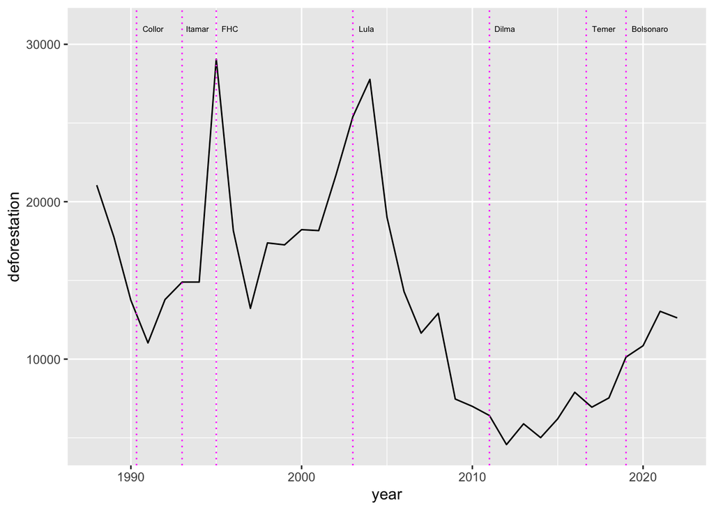

```r
degradation %>%
  ggplot( aes( year, deforestation ) ) +
  geom_line() +
  geom_vline( xintercept = c(1990.33, 1993, 1995, 2003, 2011, 2016.67, 2019),
              color = "magenta", linetype = 3 ) +
  annotate( "text",
            x = c(1991.3, 1993.9, 1995.8, 2003.8, 2011.9, 2017.7, 2020.4),
            y = 31000,
            label = c("Collor", "Itamar", "FHC", "Lula", "Dilma", "Temer", "Bolsonaro"),
            size = 2)
```

Em 2004, sob o comando da ministra do meio ambiente, Marina Silva, foi criado o PPCDAm com o objetivo de diminuir o desmatamento na Amazônia e criar condições de desenvolvimento sustentável na região. Utilize a internet para saber um pouco mais sobre o PPCDAm.

7. Inspire-se no gráfico anterior e crie um gráfico de desmatamento ao longo dos anos com uma linha vertical laranja no ano de 2004 e o texto “PPCDAm” bem disposto em tamanho 4. O que o seu gráfico, conjuntamente ao gráfico acima e sua pesquisa na internet, podem explicar sobre o desmatamento no Brasil?

# Parte 3

*El Niño* e *La Niña* são fenômenos climáticos importantes que podem afetar o regime de chuvas e, consequentemente, focos de incêndio e desmatamento. Nos exercícios seguintes, você irão realizar alguma análise, superficial, sobre esses fenômenos.

8. Faça um **boxplot** do fenômeno contra as queimadas a partir de 1999. Isto porque não há dados anteriormente a essa data. O que você observa?
9. Apresente um gráfico que resuma a relação entre os fenômenos ocorridos, a partir de 1999, por governo.
10. Atribua o tipo `factor` à variável `severity`. Em seguida ordene os níveis da variável por meio do comando `ordered`. Consulte o **help**.
11. Faça um **boxplot** da severidade contra as queimadas separado por fenômeno. Lembre-se que não há dados antes de 1999. O que você observa?
12. Apresente um gráfico com a severidade de cada fenômeno, para cada governo, a partir de 1999. Para uma melhor visualização adicione os argumentos `fig.height=4` e `fig.width=10` ao *chunk*.

# Entrega da avaliação

- Gere um arquivo **html** da sua avaliação e faça a entrega do arquivo na tarefa assinalada no SIGAA.
- Se o laboratório for realizado em duplas, apenas um membro da dupla deve realizar a entrega.